# *Orcinus orca* Population Trends in North American Marine Habitats since 1970

By Zoja Manček Páli, for the ZSL and WWF November 20th, 2023

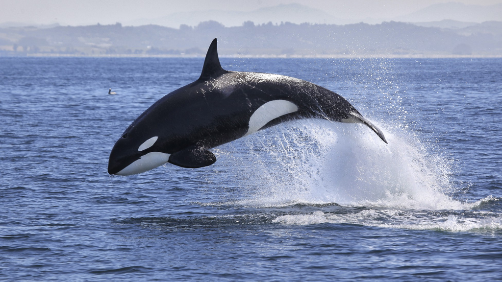

Image credit: Tory Kallman / Shutterstock

## Introduction and background:

Due to the increasing speed of the effects of climate change and human pressures on habitats, it is increasingly important to understand how various species are reacting to these changes over time, with particular focus on endangered and protected species. The orca (or killer whale; *Orcinus orca*) is a protected marine mammal species listed as critically endangered by the IUCN (Reeves *et al*., 2017).

Understanding how *O. orca* responds to these external stressors is crucial for marine conservation efforts as this species is often considered a sentinel for the health of marine ecosystems: changes in their abundance may signal broader ecological disruptions (Ford, 2009). The focus of this study is thus to evaluate the changes in population of *O. orca* over time in North American marine habitats.

## The trends:

Our study found that *O. orca* abundances show variation over time, as well as within different habitats - see Figure 1 (left and right, respectfully).

[figure not shown]

fig 1

While we saw significant variation within each site (Figure 2, left), we did not see significant variation between the two countries (Figure 2, right).

[figure not shown]

**Figure 2** shows the trends of the *O. orcinus* abundance data between the different sites and countries. The box plots show the distribution of the data, with the box plots showing the minimum, first quartile, median, third quartile, and maximum abundance values for each site/country.

## Statistical modelling:

To understand the relationship between *O. orca* abundance and time, we modelled the relationship using a generalised linear mixed effect model (hereafter GLMM) as below:

```
model1 <- glmer(abundance ~ year + country + (1|location) + (1|year), family = poisson, data = orca)
```

where the population of *O. orca* is significantly impacted by time (year) and and country within which their populations are found (country). We also included two random effects (the variation between the 13 locations in the US and Canada (location), and the within-year variation (year); model1 in the script). The reason for including the inter-year and location variability as random effects is to capture any of the variability that a simpler model (that exlcudes these two variables) could not. The `family = poisson` command informs the model of the distibution of the data (in our case, a poisson distribution - see Figure 3).

[figure not shown]

fig 3

**Figure 3** shows the distribution of the *O. orcinus* abundance data, resembling a Poisson distribution.

However, after testing the GLMM assumptions on this model (which must be met to be able to correctly interpret the results of the model) - they were not met - see Figure 4.

[figure not shown]

fig 4

**Figure 4** shows the diagnostic plots of model1. The figure shows neither of the three tested assumptions were met: the relationship is not linear (left), and the variances are not equal (middle) or normally-distributed (right).

To account for these assumptions not being met, we transformed the year variable via a square-root mathematical transformation (model3 in the script):

```
model3 <- glmer(abundance ~ sqrt(year) + country + (1|location) + (1|year), family = poisson, data = orca)
```

[figure not shown]

fig3

```
gam4 <- gam(Abundance ~ s(Year, k = 40) + s(Country.list, bs = "fs") +
              s(Location.of.population, bs = "re") +
              s(Year, bs = "re", k = 40), data = orca, family = poisson)
```

## References:

Auguie, B. (2017). *gridExtra: Miscellaneous Functions for “Grid” Graphics*. R package version 2.3, https://CRAN.R-project.org/package=gridExtra.

Bates, D., Maechler, M., Bolker, B., Walker, S. (2015). Fitting Linear Mixed-Effects Models Using lme4. Journal of Statistical Software, 67(1), 1-48. doi:10.18637/jss.v067.i01.

Ford, J. K. B. (2009). K - Killer Whale: Orcinus orca. ScienceDirect. https://www.sciencedirect.com/science/article/pii/B9780123735539001504.

Fox, J., Weisberg, S. (2019). *An R Companion to Applied Regression*, Third edition. Sage, Thousand Oaks CA. https://socialsciences.mcmaster.ca/jfox/Books/Companion/.

Kallman, T. (n.d.). Killer Whale (Orcinus Orca). Shutterstock. https://www.shutterstock.com/image-photo/killer-whale-orcinus-orca-554899423?consentChanged=true.

Lüdecke, D. (2018). “ggeffects: Tidy Data Frames of Marginal Effects from Regression Models.” *Journal of Open Source Software*, *3*(26), 772. https://doi.org/10.21105/joss.00772.

Lüdecke, D. (2023). *sjPlot: Data Visualization for Statistics in Social Science*. R package version 2.8.15, https://CRAN.R-project.org/package=sjPlot.

Reeves, R., Ford, J., and Pitman, R. (2017). IUCN Red List of Threatened Species: Orcinus orca. IUCN Red List of Threatened Species. https://www.iucnredlist.org/species/15421/50368125#threats.

Sarkar D (2008). *Lattice: Multivariate Data Visualization with R*. Springer, New York. ISBN 978-0-387-75968-5, http://lmdvr.r-forge.r-project.org.

Venables, W. N. and Ripley, B. D. (2002) Modern Applied Statistics with S. Fourth Edition. Springer, New York. ISBN 0-387-95457-0

Wickham, H., Averick, M., Bryan, J., Chang, W., McGowan, L. D., François, R., Grolemund, G., Hayes, A., Henry, L., Hester, J., Kuhn, M., Pedersen, T. L., Miller, E., Bache, S. M., Müller, K., Ooms, J., Robinson, D., Seidel, D. P., Spinu, V., Takahashi, K., Vaughan, D., Wilke, C., Woo, K., Yutani, H. (2019). “Welcome to the tidyverse.” *Journal of Open Source Software*, *4*(43), 1686. https://doi.org/10.21105/joss.01686.

Wood, S.N. (2011) Fast stable restricted maximum likelihood and marginal likelihood estimation of semiparametric generalized linear models. Journal of the Royal Statistical Society (B) 73(1):3-36

WWF and ZSL (2023). The Living Planet Index. Livingplanetindex.org. https://www.livingplanetindex.org.

Zeileis, A., Hothorn, T. (2002). Diagnostic Checking in Regression Relationships. R News 2(3), 7-10. https://CRAN.R-project.org/doc/Rnews/